# Chulwalar Wuge Exports

Marvin Scott

July 25, 2016

### **Introduction**

Chulwalar is an island located near the Pacific and is well known for producing unique flowers during the Winter Season. Overall there are around four types, IE *Efak*, *Wuge*, *BlueEtel* and *RedEtel*, this document will focus on the exports related the *WUGE Flower* and determine the best fit *MODEL* that predicts and forecast values beyond 2014. This analysis would help the government of Chulwalar compare their set plan/estimates for years ahead.

### **Packages And Datasets Required**

##### Below CSV files can be found under the ChulwalarCaseStudy/Data/ folder. Below steps to import datasets into R.

**ImportedAsIsDataChulwalar** File includes the “AS IS” data.

**ImportedPlanDataChulwalar** File includes the “Plan” data.

**ImportedIndicatorsChulwalar** File includes the “indicators” data that may possibly influence exports.

```r
require(fpp)
ImportedAsIsData <- read.csv("./Data/ImportedAsIsDataChulwalar.csv", header = F, sep=";", fill = T)#select ImportedAsIsDataChulwalar.csv
ImportedPlanData <- read.csv("./Data/ImportedPlanDataChulwalar.csv", header = F, sep=";", fill = T)#select ImportedPlanDataChulwalar.csv
ImportedIndicators <- read.csv("./Data/ImportedIndicatorsChulwalar.csv", header = F, sep=";", fill = T)#select ImportedIndicatorsChulwalar.csv
```

### **Steps for Clean Data**

**AS IS Dataset for Chulwalar**

- Monthly Total Exports from 2008-2013.
- Monthly Total WUGE Exports from 2008-2013.
- Yearly Total Exports from 2008-2013.
- Monthly Total Exports for 2014.

```r
##Monthly "Total As is" from 2008-2013
TotalAsIsVector <- c(ImportedAsIsData [2:13,2],ImportedAsIsData [2:13,3],ImportedAsIsData [2:13,4],ImportedAsIsData [2:13,5],ImportedAsIsData [2:13,6],ImportedAsIsData [2:13,7])
##Monthly "WugeAsIs" from 2008-2013
WugeAsIsVector <- c(ImportedAsIsData [30:41,2],ImportedAsIsData [30:41,3],ImportedAsIsData [30:41,4],ImportedAsIsData [30:41,5],ImportedAsIsData [30:41,6],ImportedAsIsData [30:41,7])
## "YearAsIs" from 2008-2013
YearAsIsVector <- c(ImportedAsIsData [86,2],ImportedAsIsData [86,3],ImportedAsIsData [86,4],ImportedAsIsData [86,5],ImportedAsIsData [86,6],ImportedAsIsData [86,7])
##Monthly "Total As is" for 2014
TotalAsIsVector_2014 <- c(ImportedAsIsData[2:13,8])

##Convert "AS IS" data to TIME Series Format
TotalAsIs<- ts(TotalAsIsVector , start=c(2008,1), end=c(2013,12), frequency=12)
WugeAsIs <- ts(WugeAsIsVector, start=c(2008,1), end=c(2013,12), frequency=12)
YearAsIs <- ts(YearAsIsVector, start=c(2008,1), end=c(2013,12), frequency=12)
TotalAsIs_2014 <- ts(TotalAsIsVector_2014, start=c(2014,1), end=c(2014,12), frequency=12)
```

**Plan Dataset for Chulwalar**

- Monthly Total Plan Exports from 2008-2013.
- Monthly Total Plan WUGE Exports from 2008-2013.
- Yearly Total Plan Exports from 2008-2013.
- Monthly Total Plan Exports for 2014.

```r
##Monthly "Total Plan" from 2008-2013
PlanVector <- c(ImportedPlanData[2:13,2],ImportedPlanData[2:13,3],ImportedPlanData[2:13,4],ImportedPlanData[2:13,5],ImportedPlanData[2:13,6],ImportedPlanData[2:13,7])
##Monthly "Wuge Plan" from 2008-2013
WugePlanVector <- c(ImportedPlanData[30:41,2],ImportedPlanData[30:41,3],ImportedPlanData[30:41,4],ImportedPlanData[30:41,5],ImportedPlanData[30:41,6],ImportedPlanData[30:41,7])
## "Year plan" from 2008-2013
YearPlanVector <- c(ImportedPlanData[86,2],ImportedPlanData[86,3],ImportedPlanData[86,4],ImportedPlanData[86,5],ImportedPlanData[86,6],ImportedPlanData[86,7])
##Monthly "Total Plan" for 2014
PlanVector_2014 <- c(ImportedPlanData[2:13,8])

##Convert "PLAN" data to TIME Series Format
TotalPlan <- ts(PlanVector , start=c(2008,1), end=c(2013,12), frequency=12)
WugePlan <- ts(WugePlanVector, start=c(2008,1), end=c(2013,12), frequency=12)
YearPlan <- ts(YearPlanVector, start=c(2008,1), end=c(2013,12), frequency=12)
TotalPlan_2014 <- ts(PlanVector_2014, start=c(2014,1), end=c(2014,12), frequency=12)
```

**Indicator Dataset for Chulwalar**

- Monthly Change in export prices from 2008-2013 (CEPI)
- Monthly Satisfaction Index(gov) from 2008-2013
- Monthly AverageTemperatures from 2008-2013
- Monthly Births from 2008-2013
- Monthly Satisfaction Index(independent) from 2008-2013
- Total Exports from Urbano Yearly from 2008-2013
- Monthly GlobalisationPartyMembers from 2008-2013
- Monthly Average Export Price from 2008-2013
- Monthly Etel Production price index 2008-2013
- Monthly Chulwalar Index from 2008-2013
- Monthly Inflation from 2008-2013
- Spending for Chulwalar days Yearly from 2008-2013
- Monthly Chulwalar days from 2008-2013
- Monthly Influence of Chulwalar days from 2008-2013

```r
CEPIVector <- c(ImportedIndicators[2:13,2],ImportedIndicators[2:13,3],ImportedIndicators[2:13,4],ImportedIndicators[2:13,5],ImportedIndicators[2:13,6],ImportedIndicators[2:13,7])
##Convert "Indicator" data to TIME Series Format
CEPI <- ts(CEPIVector , start=c(2008,1), end=c(2013,12), frequency=12)

SIGovVector <- c(ImportedIndicators[16:27,2],ImportedIndicators[16:27,3],ImportedIndicators[16:27,4],ImportedIndicators[16:27,5],ImportedIndicators[16:27,6],ImportedIndicators[16:27,7])
##Convert "Indicator" data to TIME Series Format
SIGov <- ts(SIGovVector , start=c(2008,1), end=c(2013,12), frequency=12)


TemperatureVector <- c(ImportedIndicators[30:41,2],ImportedIndicators[30:41,3],ImportedIndicators[30:41,4],ImportedIndicators[30:41,5],ImportedIndicators[30:41,6],ImportedIndicators[30:41,7])
##Convert "Indicator" data to TIME Series Format
Temperature <- ts(TemperatureVector, start=c(2008,1), end=c(2013,12), frequency=12)

BirthsVector <- c(ImportedIndicators[44:55,2],ImportedIndicators[44:55,3],ImportedIndicators[44:55,4],ImportedIndicators[44:55,5],ImportedIndicators[44:55,6],ImportedIndicators[44:55,7])
Births <- ts(BirthsVector, start=c(2008,1), end=c(2013,12), frequency=12) ##Convert "Indicator" data to TIME Series Format

SIExternVector <- c(ImportedIndicators[58:69,2],ImportedIndicators[58:69,3],ImportedIndicators[58:69,4],ImportedIndicators[58:69,5],ImportedIndicators[58:69,6],ImportedIndicators[58:69,7])
SIExtern <- ts(SIExternVector, start=c(2008,1), end=c(2013,12), frequency=12)##Convert "Indicator" data to TIME Series Format

UrbanoExportsVector <- c(ImportedIndicators[72:83,2],ImportedIndicators[72:83,3],ImportedIndicators[72:83,4],ImportedIndicators[72:83,5],ImportedIndicators[72:83,6],ImportedIndicators[72:83,7])
UrbanoExports <- ts(UrbanoExportsVector, start=c(2008,1), end=c(2013,12), frequency=12)##Convert "Indicator" data to TIME Series Format

GlobalisationPartyMembersVector <- c(ImportedIndicators[86:97,2],ImportedIndicators[86:97,3],ImportedIndicators[86:97,4],ImportedIndicators[86:97,5],ImportedIndicators[86:97,6],ImportedIndicators[86:97,7])
##Convert "Indicator" data to TIME Series Format
GlobalisationPartyMembers <- ts(GlobalisationPartyMembersVector, start=c(2008,1), end=c(2013,12), frequency=12)

AEPIVector <- c(ImportedIndicators[100:111,2],ImportedIndicators[100:111,3],ImportedIndicators[100:111,4],ImportedIndicators[100:111,5],ImportedIndicators[100:111,6],ImportedIndicators[100:111,7])
AEPI <- ts(AEPIVector, start=c(2008,1), end=c(2013,12), frequency=12)

PPIEtelVector <- c(ImportedIndicators[114:125,2],ImportedIndicators[114:125,3],ImportedIndicators[114:125,4],ImportedIndicators[114:125,5],ImportedIndicators[114:125,6],ImportedIndicators[114:125,7])
PPIEtel <- ts(PPIEtelVector, start=c(2008,1), end=c(2013,12), frequency=12)

ChulwalarIndexVector <- c(ImportedIndicators[128:139,2],ImportedIndicators[128:139,3],ImportedIndicators[128:139,4],ImportedIndicators[128:139,5],ImportedIndicators[128:139,6],ImportedIndicators[128:139,7])
ChulwalarIndex <- ts(ChulwalarIndexVector, start=c(2008,1), end=c(2013,12), frequency=12)

InflationVector <- c(ImportedIndicators[142:153,2],ImportedIndicators[142:153,3],ImportedIndicators[142:153,4],ImportedIndicators[142:153,5],ImportedIndicators[142:153,6],ImportedIndicators[142:153,7])
Inflation <- ts(InflationVector, start=c(2008,1), end=c(2013,12), frequency=12)

IndependenceDayPresentsVector <- c(ImportedIndicators[156:167,2],ImportedIndicators[156:167,3],ImportedIndicators[156:167,4],ImportedIndicators[156:167,5],ImportedIndicators[156:167,6],ImportedIndicators[156:167,7])
IndependenceDayPresents <- ts(IndependenceDayPresentsVector, start=c(2008,1), end=c(2013,12), frequency=12)

NationalHolidaysVector <- c(ImportedIndicators[170:181,2],ImportedIndicators[170:181,3],ImportedIndicators[170:181,4],ImportedIndicators[170:181,5],ImportedIndicators[170:181,6],ImportedIndicators[170:181,7])
NationalHolidays <- ts(NationalHolidaysVector, start=c(2008,1), end=c(2013,12), frequency=12)

InfluenceNationalHolidaysVector <- c(ImportedIndicators[184:195,2],ImportedIndicators[184:195,3],ImportedIndicators[184:195,4],ImportedIndicators[184:195,5],ImportedIndicators[184:195,6],ImportedIndicators[184:195,7])
InfluenceNationalHolidays <- ts(InfluenceNationalHolidaysVector, start=c(2008,1), end=c(2013,12), frequency=12)
```

### **Analysis**

##### **Correlation Analysis to evaluate relationship between AS IS Exports and Plan Exports from 2008-2013**

- AS IS Monthly Totals from 2008-2013 and “PLAN” Monthly Totals from 2008-2013
- AS IS WUGE Monthly Totals from 2008-2013 and “PLAN” WUGE Monthly Totals from 2008-2013
- AS IS Year End Totals from 2008-2013 and “PLAN” Year End Totals from 2008-2013

```r
cbind(cor(TotalAsIs, TotalPlan) ,cor(WugeAsIs, WugePlan),cor(YearAsIs, YearPlan))
```

```
##           [,1]      [,2]      [,3]
## [1,] 0.9183402 0.8788474 0.9627401
```

##### **Correlation Analysis to evaluate relationship between AS IS Exports and Indicator factors from 2008-2013**

- Monthly Change in export prices from 2008-2013 and AS IS Monthly Total from 2008-2013
- Monthly Change in export prices from 2008-2013 and AS IS WUGE Monthly Total from 2008-2013
- Monthly Change in export prices from 2008-2013 and AS IS Year End Total 2008-2013

```r
cbind(cor(TotalAsIs, CEPI) ,cor(WugeAsIs, CEPI),cor(YearAsIs, CEPI))
```

```
##          [,1]      [,2]       [,3]
## [1,] 0.663925 0.7618551 0.07542803
```

- Monthly Satisfaction Index(gov) from 2008-2013 and AS IS Monthly Total from 2008-2013
- Monthly Satisfaction Index(gov) from 2008-2013 and AS IS WUGE Monthly Total from 2008-2013
- Monthly Satisfaction Index(gov) from 2008-2013 and AS IS Year End Total 2008-2013

```r
cbind(cor(TotalAsIs, SIGov) ,cor(WugeAsIs, SIGov),cor(YearAsIs, SIGov))
```

```
##           [,1]      [,2]         [,3]
## [1,] 0.2007768 0.3030266 -0.003979345
```

- Monthly AverageTemperatures from 2008-2013 and AS IS Monthly Total from 2008-2013
- Monthly AverageTemperatures from 2008-2013 and AS IS WUGE Monthly Total from 2008-2013
- Monthly AverageTemperatures from 2008-2013 and AS IS Year End Total 2008-2013

```r
cbind(cor(TotalAsIs, Temperature),cor(WugeAsIs, Temperature),cor(YearAsIs, Temperature))
```

```
##            [,1]       [,2]        [,3]
## [1,] -0.3429684 -0.2045082 -0.01865858
```

- Monthly Births from 2008-2013 and AS IS Monthly Total from 2008-2013
- Monthly Births from 2008-2013 and AS IS WUGE Monthly Total from 2008-2013
- Monthly Births from 2008-2013 and AS IS Year End Total 2008-2013

```r
cbind(cor(TotalAsIs, Births),cor(WugeAsIs, Births),cor(YearAsIs, Births))
```

```
##            [,1]         [,2]       [,3]
## [1,] -0.1190228 -0.007371339 -0.3370649
```

- Monthly Satisfaction Index(independent) from 2008-2013 and AS IS Monthly Total from 2008-2013
- Monthly Satisfaction Index(independent) from 2008-2013 and AS IS WUGE Monthly Total from 2008-2013
- Monthly Satisfaction Index(independent) from 2008-2013 and AS IS Year End Total 2008-2013

```r
cbind(cor(TotalAsIs, SIExtern), cor(WugeAsIs, SIExtern),cor(YearAsIs, SIExtern))
```

```
##           [,1]      [,2]       [,3]
## [1,] 0.5883122 0.6786552 0.04247286
```

- Total Exports from Urbano Yearly from 2008-2013 and AS IS Monthly Total from 2008-2013
- Total Exports from Urbano Yearly from 2008-2013 and AS IS WUGE Monthly Total from 2008-2013
- Total Exports from Urbano Yearly from 2008-2013 and AS IS Year End Total 2008-2013

```r
cbind(cor(TotalAsIs, UrbanoExports),cor(WugeAsIs, UrbanoExports),cor(YearAsIs, UrbanoExports))
```

```
##          [,1]      [,2]        [,3]
## [1,] 0.638178 0.7118468 1.55797e-20
```

- Monthly Monthly GlobalisationPartyMembers from 2008-2013 and AS IS Monthly Total from 2008-2013
- Monthly Monthly GlobalisationPartyMembers from 2008-2013 and AS IS WUGE Monthly Total from 2008-2013
- Monthly Monthly GlobalisationPartyMembers from 2008-2013 and AS IS Year End Total 2008-2013

```r
cbind(cor(TotalAsIs, GlobalisationPartyMembers),cor(WugeAsIs, GlobalisationPartyMembers),cor(YearAsIs, GlobalisationPartyMembers))
```

```
##          [,1]      [,2]          [,3]
## [1,] 0.630084 0.7193864 -2.592044e-20
```

- Monthly Average Export Price from 2008-2013 and AS IS Monthly Total from 2008-2013
- Monthly Average Export Price from 2008-2013 and AS IS WUGE Monthly Total from 2008-2013
- Monthly Average Export Price from 2008-2013 and AS IS Year End Total 2008-2013

```r
cbind(cor(TotalAsIs, AEPI),cor(WugeAsIs, AEPI),cor(YearAsIs, AEPI))
```

```
##          [,1]      [,2]       [,3]
## [1,] 0.625232 0.7159733 0.03381806
```

- Monthly Etel Production price from 2008-2013 and AS IS Monthly Total from 2008-2013
- Monthly Etel Production price from 2008-2013 and AS IS WUGE Monthly Total from 2008-2013
- Monthly Etel Production price from 2008-2013 and AS IS Year End Total 2008-2013

```r
cbind(cor(TotalAsIs, PPIEtel), cor(WugeAsIs, PPIEtel),cor(YearAsIs, PPIEtel))
```

```
##           [,1]      [,2]       [,3]
## [1,] 0.4836129 0.4920865 0.02318808
```

- Monthly Chulwalar Index from 2008-2013 and AS IS Monthly Total from 2008-2013
- Monthly Chulwalar Index from 2008-2013 and AS IS WUGE Monthly Total from 2008-2013
- Monthly Chulwalar Index from 2008-2013 and AS IS Year End Total 2008-2013

```r
cbind(cor(TotalAsIs, ChulwalarIndex),cor(WugeAsIs, ChulwalarIndex),cor(YearAsIs, ChulwalarIndex))
```

```
##           [,1]      [,2]       [,3]
## [1,] 0.4837017 0.5721568 0.06006468
```

- Monthly Inflation from 2008-2013 and AS IS Monthly Total from 2008-2013
- Monthly Inflation from 2008-2013 and AS IS WUGE Monthly Total from 2008-2013
- Monthly Inflation from 2008-2013 and AS IS Year End Total 2008-2013

```r
cbind(cor(TotalAsIs, Inflation),cor(WugeAsIs, Inflation),cor(YearAsIs, Inflation))
```

```
##             [,1]       [,2]        [,3]
## [1,] 0.002438708 0.03191332 -0.05626106
```

- Spending for Chulwalar days Yearly from 2008-2013 and AS IS Monthly Total from 2008-2013
- Spending for Chulwalar days Yearly from 2008-2013 and AS IS WUGE Monthly Total from 2008-2013
- Spending for Chulwalar days Yearly from 2008-2013 and AS IS Year End Total 2008-2013

```r
cbind(cor(TotalAsIs, IndependenceDayPresents),cor(WugeAsIs, IndependenceDayPresents),cor(YearAsIs, IndependenceDayPresents))
```

```
##           [,1]      [,2]         [,3]
## [1,] 0.4359522 0.4892437 9.718683e-21
```

- Monthly Chulwalar days from 2008-2013 and AS IS Monthly Total from 2008-2013
- Monthly Chulwalar days from 2008-2013 and AS IS WUGE Monthly Total from 2008-2013
- Monthly Chulwalar days from 2008-2013 and AS IS Year End Total 2008-2013

```r
cbind(cor(TotalAsIs, NationalHolidays),cor(WugeAsIs, NationalHolidays),cor(YearAsIs, NationalHolidays))
```

```
##              [,1]       [,2]      [,3]
## [1,] -0.007883708 0.06505569 0.3605665
```

- Monthly Influence of Chulwalar days from 2008-2013 and AS IS Monthly Total from 2008-2013
- Monthly Influence of Chulwalar days from 2008-2013 and AS IS WUGE Monthly Total from 2008-2013
- Monthly Influence of Chulwalar days from 2008-2013 and AS IS Year End Total 2008-2013

```r
cbind(cor(TotalAsIs, InfluenceNationalHolidays),cor(WugeAsIs, InfluenceNationalHolidays),cor(YearAsIs, InfluenceNationalHolidays))
```

```
##           [,1]      [,2]      [,3]
## [1,] 0.3717463 0.3712288 0.3592186
```

##### **Linear Regression Analysis between AS IS and PLAN datasets**

- Plan Monthly Total from 2008-2013 and AS IS Monthly Total from 2008-2013
- Plan WUGE Monthly Total from 2008-2013 and AS IS WUGE Monthly Total from 2008-2013
- Plan Year End Total 2008-2013 and AS IS Year End Total 2008-2013

```r
##Linear Model Fit
TotalAsIs_lm <- lm(TotalAsIs ~ TotalPlan , data = TotalAsIs)
summary(TotalAsIs_lm)
```

```
##
## Call:
## lm(formula = TotalAsIs ~ TotalPlan, data = TotalAsIs)
##
## Residuals:
##     Min      1Q  Median      3Q     Max
## -770214 -196776   26017  182579  672705
##
## Coefficients:
##              Estimate Std. Error t value Pr(>|t|)
## (Intercept) 8.959e+04  1.521e+05   0.589    0.558
## TotalPlan   9.627e-01  4.959e-02  19.413   <2e-16 ***
## ---
## Signif. codes:  0 '***' 0.001 '**' 0.01 '*' 0.05 '.' 0.1 ' ' 1
##
## Residual standard error: 332600 on 70 degrees of freedom
## Multiple R-squared:  0.8433, Adjusted R-squared:  0.8411
## F-statistic: 376.9 on 1 and 70 DF,  p-value: < 2.2e-16
```

```r
##Linear Model Fit
WugeAsIs_lm <- lm(WugeAsIs ~ WugePlan , data = WugeAsIs)
summary(WugeAsIs_lm)
```

```
##
## Call:
## lm(formula = WugeAsIs ~ WugePlan, data = WugeAsIs)
##
## Residuals:
##     Min      1Q  Median      3Q     Max
## -225162  -55052   -2998   32989  204947
##
## Coefficients:
##              Estimate Std. Error t value Pr(>|t|)
## (Intercept) 4.620e+04  3.582e+04    1.29    0.201
## WugePlan    9.178e-01  5.955e-02   15.41   <2e-16 ***
## ---
## Signif. codes:  0 '***' 0.001 '**' 0.01 '*' 0.05 '.' 0.1 ' ' 1
##
## Residual standard error: 80220 on 70 degrees of freedom
## Multiple R-squared:  0.7724, Adjusted R-squared:  0.7691
## F-statistic: 237.5 on 1 and 70 DF,  p-value: < 2.2e-16
```

```r
##Linear Model Fit
YearAsIs_lm <- lm(YearAsIs ~ YearPlan , data = YearAsIs)
summary(YearAsIs_lm)
```

```
##
## Call:
## lm(formula = YearAsIs ~ YearPlan, data = YearAsIs)
##
## Residuals:
##      Min       1Q   Median       3Q      Max
## -2844175 -1556647   216381  1735056  2233004
##
## Coefficients:
##              Estimate Std. Error t value Pr(>|t|)
## (Intercept) 6.935e+05  1.181e+06   0.587    0.559
## YearPlan    9.735e-01  3.268e-02  29.786   <2e-16 ***
## ---
## Signif. codes:  0 '***' 0.001 '**' 0.01 '*' 0.05 '.' 0.1 ' ' 1
##
## Residual standard error: 1787000 on 70 degrees of freedom
## Multiple R-squared:  0.9269, Adjusted R-squared:  0.9258
## F-statistic: 887.2 on 1 and 70 DF,  p-value: < 2.2e-16
```

- Plan Monthly Total from 2008-2013 and AS IS Monthly Total from 2008-2013
- Plan WUGE Monthly Total from 2008-2013 and AS IS WUGE Monthly Total from 2008-2013
- Plan Year End Total 2008-2013 and AS IS Year End Total 2008-2013

```r
##Linear Model Fit including trend and seasonality components.
TotalAsIs_tslm <- tslm(TotalAsIs ~ TotalPlan )
summary(TotalAsIs_tslm)
```

```
##
## Call:
## tslm(formula = TotalAsIs ~ TotalPlan)
##
## Residuals:
##     Min      1Q  Median      3Q     Max
## -770214 -196776   26017  182579  672705
##
## Coefficients:
##              Estimate Std. Error t value Pr(>|t|)
## (Intercept) 8.959e+04  1.521e+05   0.589    0.558
## TotalPlan   9.627e-01  4.959e-02  19.413   <2e-16 ***
## ---
## Signif. codes:  0 '***' 0.001 '**' 0.01 '*' 0.05 '.' 0.1 ' ' 1
##
## Residual standard error: 332600 on 70 degrees of freedom
## Multiple R-squared:  0.8433, Adjusted R-squared:  0.8411
## F-statistic: 376.9 on 1 and 70 DF,  p-value: < 2.2e-16
```

```r
##Linear Model Fit including trend and seasonality components.
WugeAsIs_lm <- lm(WugeAsIs ~ WugePlan , data = WugeAsIs)
summary(WugeAsIs_lm)
```

```
##
## Call:
## lm(formula = WugeAsIs ~ WugePlan, data = WugeAsIs)
##
## Residuals:
##     Min      1Q  Median      3Q     Max
## -225162  -55052   -2998   32989  204947
##
## Coefficients:
##              Estimate Std. Error t value Pr(>|t|)
## (Intercept) 4.620e+04  3.582e+04    1.29    0.201
## WugePlan    9.178e-01  5.955e-02   15.41   <2e-16 ***
## ---
## Signif. codes:  0 '***' 0.001 '**' 0.01 '*' 0.05 '.' 0.1 ' ' 1
##
## Residual standard error: 80220 on 70 degrees of freedom
## Multiple R-squared:  0.7724, Adjusted R-squared:  0.7691
## F-statistic: 237.5 on 1 and 70 DF,  p-value: < 2.2e-16
```

```r
##Linear Model Fit including trend and seasonality components.
YearAsIs_lm <- lm(YearAsIs ~ YearPlan , data = YearAsIs)
summary(YearAsIs_lm)
```

```
##
## Call:
## lm(formula = YearAsIs ~ YearPlan, data = YearAsIs)
##
## Residuals:
##      Min       1Q   Median       3Q      Max
## -2844175 -1556647   216381  1735056  2233004
##
## Coefficients:
##              Estimate Std. Error t value Pr(>|t|)
## (Intercept) 6.935e+05  1.181e+06   0.587    0.559
## YearPlan    9.735e-01  3.268e-02  29.786   <2e-16 ***
## ---
## Signif. codes:  0 '***' 0.001 '**' 0.01 '*' 0.05 '.' 0.1 ' ' 1
##
## Residual standard error: 1787000 on 70 degrees of freedom
## Multiple R-squared:  0.9269, Adjusted R-squared:  0.9258
## F-statistic: 887.2 on 1 and 70 DF,  p-value: < 2.2e-16
```

##### **Time Series Analysis** for “AS IS” datasets

STL function used to separate the data, seasonality, trend and remainder and determines the variation of each component

```r
TotalAsIs_stl <- stl(TotalAsIs, s.window=5)
WugeAsIs_stl <- stl(WugeAsIs, s.window=5)
YearAsIs_stl <- stl(YearAsIs, s.window=5)
```

##### **Plot Analysis**

- AS IS and PLAN Plot Diagrams
- Plot AS IS WUGE Monthly 2008-2013

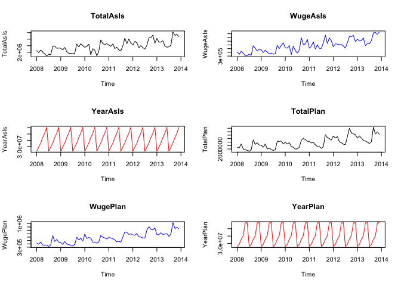

```r
par(mfrow=c(3,2))
##Plot "AS IS" datasets
plot(TotalAsIs, col="black", main="TotalAsIs")
plot(WugeAsIs, col="blue", main="WugeAsIs")
plot(YearAsIs, col="red", main="YearAsIs")
##Plot "PLAN" datasets
plot(TotalPlan , col="black", main="TotalPlan")
plot(WugePlan, col="blue", main="WugePlan")
plot(YearPlan, col="red", main="YearPlan")
```

* STL Plots for AS IS WUGE Monthly 2008-2013 * STL Plots for AS IS Totals Monthly 2008-2013  
* STL Plots for AS IS Year End 2008-2013

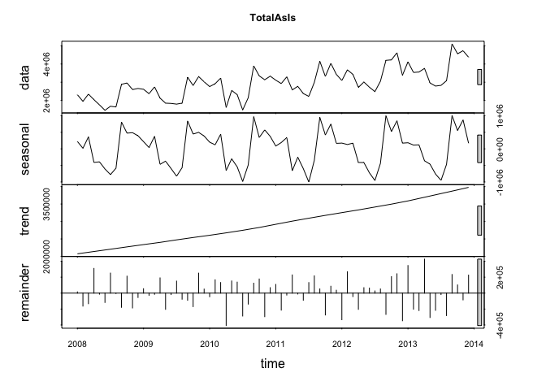

```r
par(mfrow=c(3,2))
plot(TotalAsIs_stl, col="black", main="TotalAsIs")
```

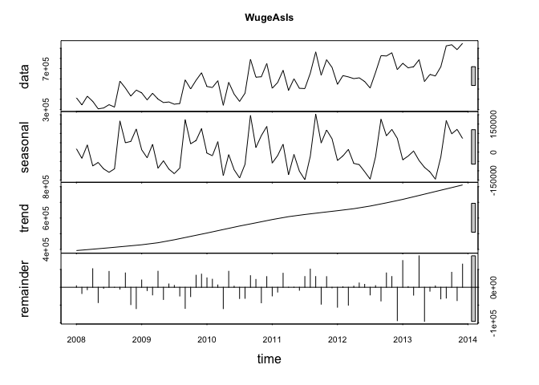

```r
plot(WugeAsIs_stl, col="black", main="WugeAsIs")
```

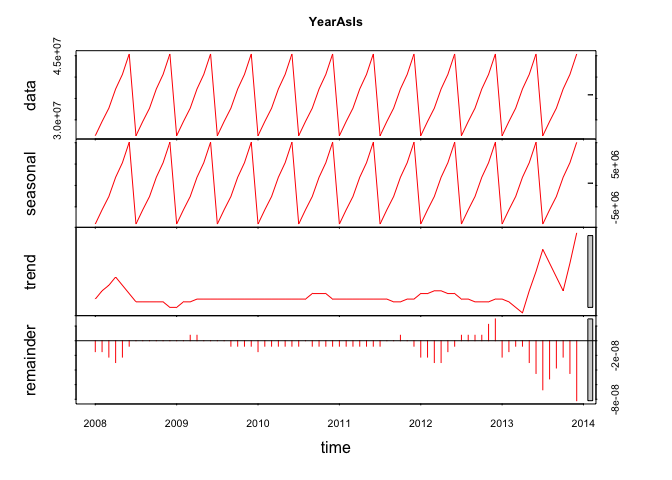

```r
plot(YearAsIs_stl, col="red", main="YearAsIs")
```

* Trend Plots for AS IS WUGE Monthly 2008-2013 * Trend Plots for AS IS Totals Monthly 2008-2013  
* Trend Plots for AS IS Year End 2008-2013

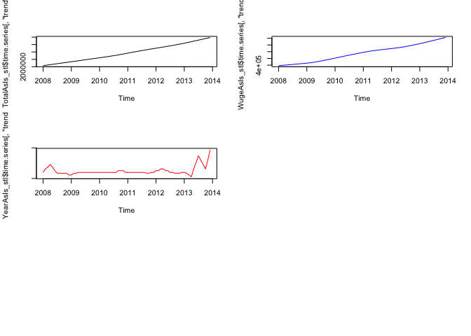

```r
par(mfrow=c(3,2))
plot(TotalAsIs_stl$time.series[,"trend"], col="black")
plot(WugeAsIs_stl$time.series[,"trend"], col="blue")
plot(YearAsIs_stl$time.series[,"trend"], col="red")
```

* Monthly Seasonal Plots for AS IS WUGE Monthly 2008-2013 * Monthly Seasonal Plots for AS IS Totals Monthly 2008-2013  
* Monthly Seasonal Plots for AS IS Year End 2008-2013

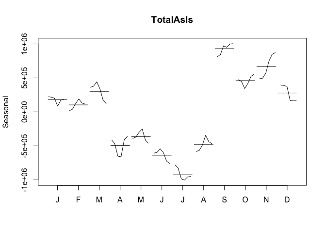

```r
monthplot(TotalAsIs_stl$time.series[,"seasonal"], main="TotalAsIs", ylab="Seasonal")
```

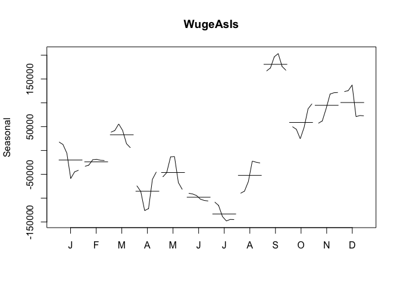

```r
monthplot(WugeAsIs_stl$time.series[,"seasonal"], main="WugeAsIs", ylab="Seasonal")
```

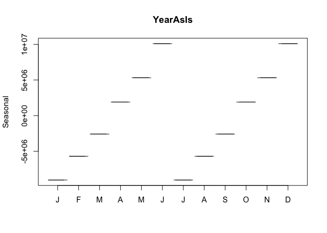

```r
monthplot(YearAsIs_stl$time.series[,"seasonal"], main="YearAsIs", ylab="Seasonal")
```

### **Exploring Forcast Models**

###### **Simple expontential smoothing.**

```r
##2014 Monthly Forcast values
Model_ses <- ses(TotalAsIs, h=12)
summary(Model_ses)
```

```
##
## Forecast method: Simple exponential smoothing
##
## Model Information:
## Simple exponential smoothing
##
## Call:
##  ses(x = TotalAsIs, h = 12)
##
##   Smoothing parameters:
##     alpha = 0.671
##
##   Initial states:
##     l = 2173226.7433
##
##   sigma:  609507
##
##      AIC     AICc      BIC
## 2230.058 2230.232 2234.612
##
## Error measures:
##                    ME   RMSE      MAE       MPE     MAPE     MASE
## Training set 47469.84 609507 429997.1 -1.511008 15.02336 1.172074
##                    ACF1
## Training set 0.02384493
##
## Forecasts:
##          Point Forecast   Lo 80   Hi 80   Lo 95   Hi 95
## Jan 2014        4466448 3685333 5247562 3271836 5661059
## Feb 2014        4466448 3525801 5407094 3027853 5905042
## Mar 2014        4466448 3389650 5543245 2819628 6113267
## Apr 2014        4466448 3268880 5664015 2634926 6297969
## May 2014        4466448 3159220 5773675 2467215 6465680
## Jun 2014        4466448 3058072 5874823 2312524 6620371
## Jul 2014        4466448 2963718 5969177 2168221 6764674
## Aug 2014        4466448 2874947 6057948 2032458 6900437
## Sep 2014        4466448 2790873 6142022 1903878 7029017
## Oct 2014        4466448 2710821 6222074 1781448 7151447
## Nov 2014        4466448 2634263 6298632 1664363 7268532
## Dec 2014        4466448 2560778 6372117 1551977 7380918
```

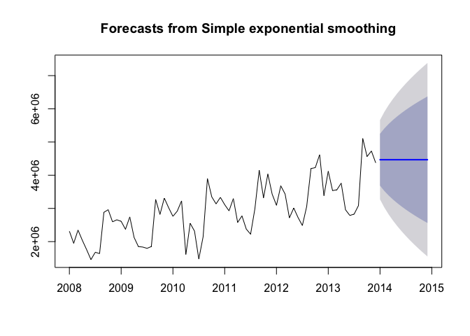

```r
plot(Model_ses)
```

#### **HOLT’S Method.**

###### **Holt’s linear Method**

```r
##2014 Monthly Forcast values
Model_holt_1 <- holt(TotalAsIs,h=12)
summary(Model_holt_1)
```

```
##
## Forecast method: Holt's method
##
## Model Information:
## Holt's method
##
## Call:
##  holt(x = TotalAsIs, h = 12)
##
##   Smoothing parameters:
##     alpha = 0.6571
##     beta  = 1e-04
##
##   Initial states:
##     l = 2040390.7764
##     b = 45050.7514
##
##   sigma:  608119.1
##
##      AIC     AICc      BIC
## 2233.730 2234.327 2242.837
##
## Error measures:
##                    ME     RMSE      MAE      MPE     MAPE     MASE
## Training set -16586.9 608119.1 441110.7 -3.88925 15.75307 1.202367
##                    ACF1
## Training set 0.03462672
##
## Forecasts:
##          Point Forecast   Lo 80   Hi 80   Lo 95   Hi 95
## Jan 2014        4536367 3757031 5315703 3344475 5728259
## Feb 2014        4581298 3648703 5513894 3155016 6007580
## Mar 2014        4626230 3562188 5690271 2998918 6253541
## Apr 2014        4671161 3490181 5852141 2865008 6477314
## May 2014        4716092 3428721 6003463 2747228 6684956
## Jun 2014        4761024 3375378 6146669 2641862 6880185
## Jul 2014        4805955 3328531 6283379 2546429 7065480
## Aug 2014        4850886 3287035 6414738 2459182 7242591
## Sep 2014        4895818 3250047 6541588 2378829 7412807
## Oct 2014        4940749 3216925 6664573 2304387 7577111
## Nov 2014        4985680 3187164 6784196 2235088 7736273
## Dec 2014        5030612 3160363 6900860 2170314 7890909
```

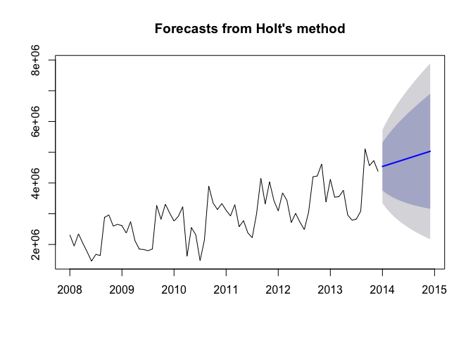

```r
plot(Model_holt_1)
```

###### **Holt’s exponential Method.**

```r
##2014 Monthly Forcast values
Model_holt_2<- holt(TotalAsIs, exponential=TRUE,h=12)
summary(Model_holt_2)
```

```
##
## Forecast method: Holt's method with exponential trend
##
## Model Information:
## Holt's method with exponential trend
##
## Call:
##  holt(x = TotalAsIs, h = 12, exponential = TRUE)
##
##   Smoothing parameters:
##     alpha = 0.6637
##     beta  = 1e-04
##
##   Initial states:
##     l = 2041538.9468
##     b = 1.0029
##
##   sigma:  0.2438
##
##      AIC     AICc      BIC
## 2251.010 2251.607 2260.116
##
## Error measures:
##                    ME     RMSE      MAE       MPE     MAPE     MASE
## Training set 37825.61 609787.5 433018.9 -1.838214 15.18487 1.180311
##                    ACF1
## Training set 0.02918287
##
## Forecasts:
##          Point Forecast   Lo 80   Hi 80   Lo 95    Hi 95
## Jan 2014        4488281 3054652 5869193 2259877  6663821
## Feb 2014        4502175 2803604 6208397 2141473  7298131
## Mar 2014        4516113 2647478 6502146 1918452  7838903
## Apr 2014        4530094 2487164 6864693 1798950  8404273
## May 2014        4544118 2362964 6994384 1644382  8937035
## Jun 2014        4558186 2240607 7330755 1541354  9570742
## Jul 2014        4572297 2135282 7597373 1425318  9967967
## Aug 2014        4586452 2092970 7731200 1306683 10412918
## Sep 2014        4600650 1947618 7986275 1272059 10794285
## Oct 2014        4614893 1898712 8088400 1215183 11359052
## Nov 2014        4629180 1762111 8276226 1133477 11657769
## Dec 2014        4643510 1726425 8391900 1066065 12141707
```

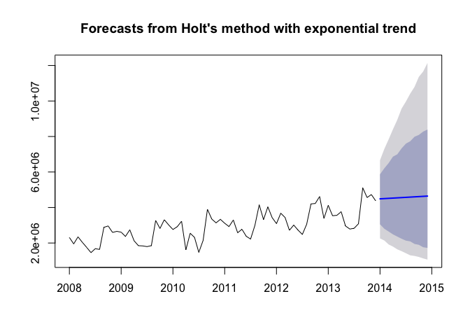

```r
plot(Model_holt_2)
```

###### **Holt’s Damped Linear Method.**

```r
##2014 Monthly Forcast values
Model_holt_3 <- holt(TotalAsIs, damped=TRUE,h=12)
summary(Model_holt_3)
```

```
##
## Forecast method: Damped Holt's method
##
## Model Information:
## Damped Holt's method
##
## Call:
##  holt(x = TotalAsIs, h = 12, damped = TRUE)
##
##   Smoothing parameters:
##     alpha = 0.6613
##     beta  = 2e-04
##     phi   = 0.98
##
##   Initial states:
##     l = 2040392.5761
##     b = 45053.25
##
##   sigma:  608787.2
##
##      AIC     AICc      BIC
## 2235.888 2236.797 2247.272
##
## Error measures:
##                    ME     RMSE      MAE       MPE     MAPE     MASE
## Training set 15578.94 608787.2 436909.7 -2.797612 15.46526 1.190916
##                    ACF1
## Training set 0.03351419
##
## Forecasts:
##          Point Forecast   Lo 80   Hi 80   Lo 95   Hi 95
## Jan 2014        4483618 3703426 5263811 3290417 5676819
## Feb 2014        4493914 3558436 5429391 3063224 5924603
## Mar 2014        4504003 3435520 5572486 2869899 6138107
## Apr 2014        4513891 3327168 5700614 2698955 6328827
## May 2014        4523581 3229332 5817829 2544198 6502963
## Jun 2014        4533077 3139534 5926619 2401837 6664316
## Jul 2014        4542383 3056128 6028638 2269352 6815413
## Aug 2014        4551503 2977955 6125051 2144969 6958036
## Sep 2014        4560440 2904162 6216719 2027381 7093499
## Oct 2014        4569199 2834101 6304298 1915595 7222803
## Nov 2014        4577783 2767264 6388301 1808834 7346732
## Dec 2014        4586195 2703249 6469141 1706477 7465913
```

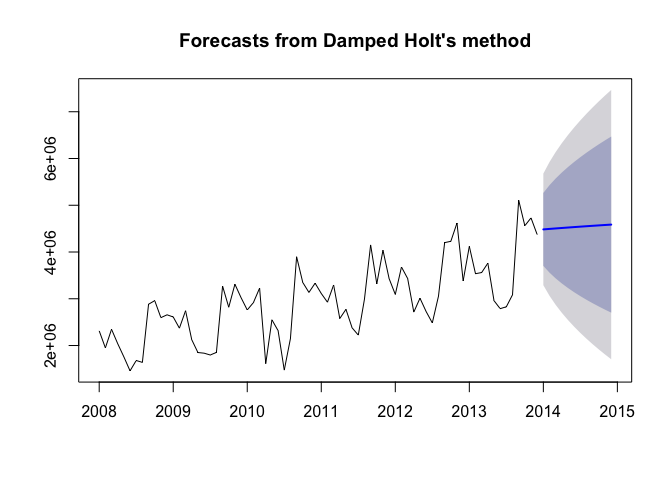

```r
plot(Model_holt_3)
```

###### **Holt’s Damped Exponential Method.**

```r
##2014 Monthly Forcast values
Model_holt_4 <- holt(TotalAsIs, exponential=TRUE, damped=TRUE,h=12)
summary(Model_holt_4)
```

```
##
## Forecast method: Damped Holt's method with exponential trend
##
## Model Information:
## Damped Holt's method with exponential trend
##
## Call:
##  holt(x = TotalAsIs, h = 12, damped = TRUE, exponential = TRUE)
##
##   Smoothing parameters:
##     alpha = 0.6679
##     beta  = 1e-04
##     phi   = 0.9799
##
##   Initial states:
##     l = 2041541.9705
##     b = 1.0019
##
##   sigma:  0.2449
##
##      AIC     AICc      BIC
## 2253.216 2254.125 2264.600
##
## Error measures:
##                    ME     RMSE      MAE       MPE     MAPE     MASE
## Training set 46119.56 609906.7 432069.1 -1.549114 15.11987 1.177722
##                   ACF1
## Training set 0.0254941
##
## Forecasts:
##          Point Forecast   Lo 80   Hi 80     Lo 95    Hi 95
## Jan 2014        4470648 3068427 5832895 2411545.8  6605349
## Feb 2014        4473164 2836533 6157837 2116191.6  7258714
## Mar 2014        4475630 2688880 6477062 1947691.6  7779982
## Apr 2014        4478047 2494751 6726139 1791681.7  8404446
## May 2014        4480418 2328331 6934993 1634269.9  8802478
## Jun 2014        4482742 2199797 7107101 1506463.2  9276128
## Jul 2014        4485020 2118319 7378928 1436173.0  9819616
## Aug 2014        4487253 1986118 7440981 1281686.6 10138804
## Sep 2014        4489443 1943779 7661226 1260296.4 10295992
## Oct 2014        4491589 1808174 7831832 1119098.2 11075895
## Nov 2014        4493694 1758284 7931413 1111756.7 11100837
## Dec 2014        4495757 1637358 8032709  974373.2 11818227
```

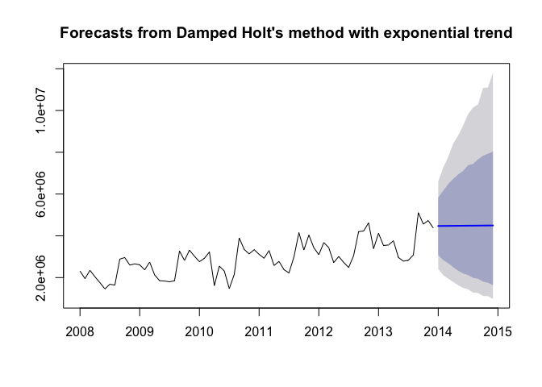

```r
plot(Model_holt_4)
```

###### **Model Comparison: Holt’s Linear, Holt’s Exponential, Holt’s Damped Linear, Holt’s Damped Exponential and Simple expontential smoothing.**

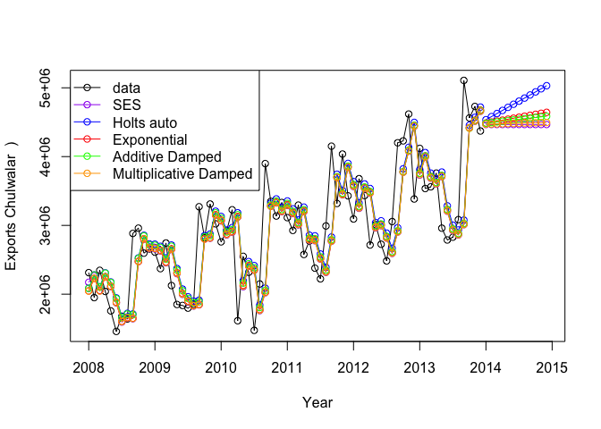

```r
plot.new()
par(mfrow=c(1,1))
plot(Model_holt_1, plot.conf=FALSE, ylab="Exports Chulwalar  )", xlab="Year", main="", fcol="white", type="o")
lines(fitted(Model_ses), col="purple", type="o")
lines(fitted(Model_holt_1), col="blue", type="o")
lines(fitted(Model_holt_2), col="red", type="o")
lines(fitted(Model_holt_3), col="green", type="o")
lines(fitted(Model_holt_4), col="orange", type="o")
lines(Model_ses$mean, col="purple", type="o")
lines(Model_holt_1$mean, col="blue", type="o")
lines(Model_holt_2$mean, col="red", type="o")
lines(Model_holt_3$mean, col="green", type="o")
lines(Model_holt_4$mean, col="orange", type="o")
legend("topleft",lty=1, col=c(1,"purple","blue","red","green","orange"), c("data", "SES","Holts auto", "Exponential", "Additive Damped", "Multiplicative Damped"),pch=1)
```

#### **HOLT’S-WINTER’S SEASONAL Method**

###### **Holt’s Winter Seasonal Additive Method.**

```r
##2014 Monthly Forcast values
Model_hw_1 <- hw(TotalAsIs ,seasonal="additive",h=12)
summary(Model_hw_1)
```

```
##
## Forecast method: Holt-Winters' additive method
##
## Model Information:
## Holt-Winters' additive method
##
## Call:
##  hw(x = TotalAsIs, h = 12, seasonal = "additive")
##
##   Smoothing parameters:
##     alpha = 0.0087
##     beta  = 0.0087
##     gamma = 1e-04
##
##   Initial states:
##     l = 2047375.0884
##     b = 22509.7631
##     s=259168.3 654942.6 474529.8 876025.2 -475155 -852844
##            -664662.5 -412596.7 -438677.3 273215 138077.9 167976.7
##
##   sigma:  241685
##
##      AIC     AICc      BIC
## 2124.856 2134.747 2161.283
##
## Error measures:
##                    ME   RMSE      MAE         MPE     MAPE      MASE
## Training set 21615.43 241685 202218.5 -0.08252109 7.329458 0.5512016
##                    ACF1
## Training set -0.2819072
##
## Forecasts:
##          Point Forecast   Lo 80   Hi 80   Lo 95   Hi 95
## Jan 2014        4141204 3831472 4450936 3667510 4614898
## Feb 2014        4147309 3837472 4457147 3673453 4621165
## Mar 2014        4318537 4008512 4628563 3844394 4792680
## Apr 2014        3642744 3332425 3953063 3168153 4117335
## May 2014        3704865 3394124 4015605 3229628 4180102
## Jun 2014        3488859 3177546 3800173 3012746 3964973
## Jul 2014        3336738 3024677 3648799 2859482 3813994
## Aug 2014        3750478 3437474 4063482 3271780 4229176
## Sep 2014        5137771 4823607 5451935 4657298 5618244
## Oct 2014        4772337 4456775 5087900 4289726 5254949
## Nov 2014        4988809 4671591 5306028 4503665 5473953
## Dec 2014        4629097 4309943 4948252 4140992 5117202
```

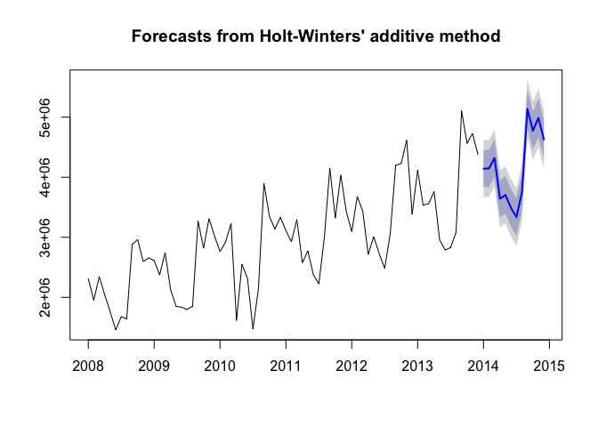

```r
plot(Model_hw_1)
```

###### **Holt’s Winter Seasonal Multiplicative Method**

```r
##2014 Monthly Forcast values
Model_hw_2 <- hw(TotalAsIs ,seasonal="multiplicative",h=12)
summary(Model_hw_2)
```

```
##
## Forecast method: Holt-Winters' multiplicative method
##
## Model Information:
## Holt-Winters' multiplicative method
##
## Call:
##  hw(x = TotalAsIs, h = 12, seasonal = "multiplicative")
##
##   Smoothing parameters:
##     alpha = 0.025
##     beta  = 0.0062
##     gamma = 1e-04
##
##   Initial states:
##     l = 2026247.531
##     b = 25395.1259
##     s=1.0933 1.232 1.1763 1.3086 0.8384 0.699
##            0.7653 0.8502 0.8596 1.0793 1.0316 1.0665
##
##   sigma:  0.0877
##
##      AIC     AICc      BIC
## 2128.303 2138.194 2164.729
##
## Error measures:
##                    ME     RMSE      MAE        MPE     MAPE      MASE
## Training set 17434.11 235296.6 191805.3 -0.3292809 7.213472 0.5228175
##                    ACF1
## Training set -0.3514421
##
## Forecasts:
##          Point Forecast   Lo 80   Hi 80   Lo 95   Hi 95
## Jan 2014        4226941 3751624 4702258 3500006 4953876
## Feb 2014        4123665 3659738 4587591 3414151 4833179
## Mar 2014        4350808 3860995 4840620 3601704 5099911
## Apr 2014        3494208 3100476 3887940 2892046 4096370
## May 2014        3484738 3091618 3877858 2883513 4085963
## Jun 2014        3162774 2805463 3520085 2616314 3709234
## Jul 2014        2912399 2582802 3241996 2408324 3416474
## Aug 2014        3521645 3122278 3921013 2910865 4132425
## Sep 2014        5540988 4911109 6170867 4577671 6504304
## Oct 2014        5020487 4448200 5592775 4145249 5895725
## Nov 2014        5299729 4693715 5905743 4372911 6226547
## Dec 2014        4740169 4196230 5284108 3908286 5572052
```

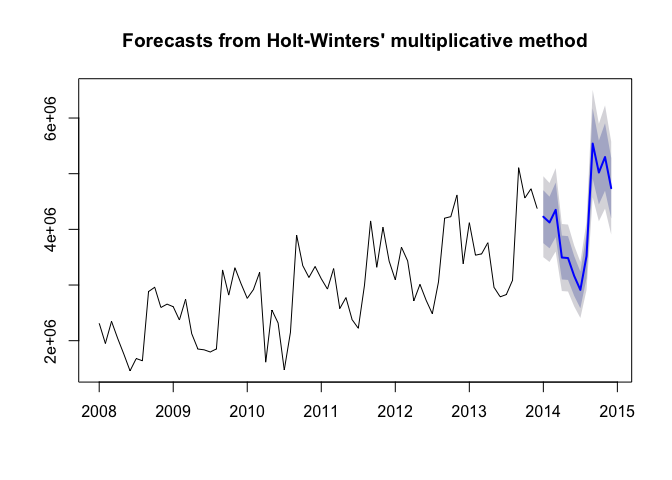

```r
plot(Model_hw_2)
```

###### **Model Comparison: Holt’s Winter Seasonal Additive vs Multiplicative**

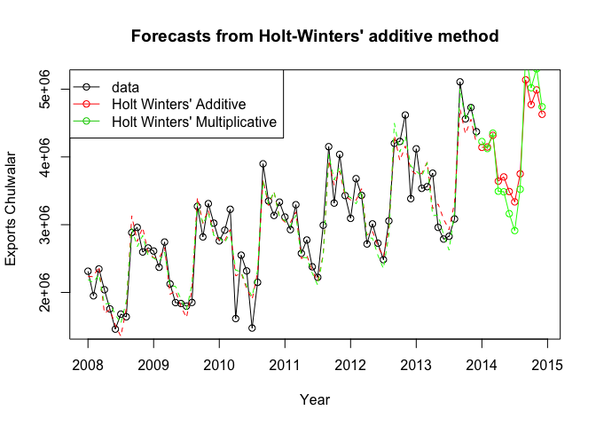

```r
plot.new()
par(mfrow=c(1,1))
plot(Model_hw_1, ylab="Exports Chulwalar  ", plot.conf=FALSE, type="o", fcol="white", xlab="Year")
lines(fitted(Model_hw_1), col="red", lty=2)
lines(fitted(Model_hw_2), col="green", lty=2)
lines(Model_hw_1$mean, type="o", col="red")
lines(Model_hw_2$mean, type="o", col="green")
legend("topleft",lty=1, pch=1, col=1:3, c("data","Holt Winters' Additive","Holt Winters' Multiplicative"))
```

### **Conclusion**

Based on the models reviewed, strongest evidence lead to infer that the **Holt’s Winter Seasonal Additive** and **Holt’s Winter Seasonal Multiplicative** models are more reliable when compared with the other models. Both these models produced the best or least **AICs**, however **Holt’s Winter Seasonal Multiplicative** produced the lower **RMSE** score when compared with **Holt’s Winter Seasonal Additive**. Although **Holt’s Winter Seasonal Additive** model had the better or lower **AIC** when compared with the multiplicative approach, as a group we suggested **Holt’s Winter Seasonal Multiplicative** as the best model to forecast Chulwalar exports since result had the lesser **RMSE**

# Chulwalar Wuge Exports

Marvin Scott

July 25, 2016

### **Packages And Datasets Required**

##### Below CSV files can be found under the ChulwalarCaseStudy/Data/ folder. Below steps to import datasets into R.

**ImportedAsIsDataChulwalar** File includes the “AS IS” data.

**ImportedPlanDataChulwalar** File includes the “Plan” data.

**ImportedIndicatorsChulwalar** File includes the “indicators” data that may possibly influence exports.

```r
require(fpp)
ImportedAsIsData <- read.csv(file.choose(), header = F, sep=";", fill = T)#select ImportedAsIsDataChulwalar.csv
ImportedPlanData <- read.csv(file.choose(), header = F, sep=";", fill = T)#select ImportedPlanDataChulwalar.csv
ImportedIndicators <- read.csv(file.choose(), header = F, sep=";", fill = T)#select ImportedIndicatorsChulwalar.csv
```

### **Steps for Clean Data**

**AS IS Dataset for Chulwalar**

- Monthly Total Exports from 2008-2013.
- Monthly Total WUGE Exports from 2008-2013.
- Yearly Total Exports from 2008-2013.
- Monthly Total Exports for 2014.

```r
##Monthly "Total As is" from 2008-2013
TotalAsIsVector <- c(ImportedAsIsData [2:13,2],ImportedAsIsData [2:13,3],ImportedAsIsData [2:13,4],ImportedAsIsData [2:13,5],ImportedAsIsData [2:13,6],ImportedAsIsData [2:13,7])
##Monthly "WugeAsIs" from 2008-2013
WugeAsIsVector <- c(ImportedAsIsData [30:41,2],ImportedAsIsData [30:41,3],ImportedAsIsData [30:41,4],ImportedAsIsData [30:41,5],ImportedAsIsData [30:41,6],ImportedAsIsData [30:41,7])
## "YearAsIs" from 2008-2013
YearAsIsVector <- c(ImportedAsIsData [86,2],ImportedAsIsData [86,3],ImportedAsIsData [86,4],ImportedAsIsData [86,5],ImportedAsIsData [86,6],ImportedAsIsData [86,7])
##Monthly "Total As is" for 2014
TotalAsIsVector_2014 <- c(ImportedAsIsData[2:13,8])

##Convert "AS IS" data to TIME Series Format
TotalAsIs<- ts(TotalAsIsVector , start=c(2008,1), end=c(2013,12), frequency=12)
WugeAsIs <- ts(WugeAsIsVector, start=c(2008,1), end=c(2013,12), frequency=12)
YearAsIs <- ts(YearAsIsVector, start=c(2008,1), end=c(2013,12), frequency=12)
TotalAsIs_2014 <- ts(TotalAsIsVector_2014, start=c(2014,1), end=c(2014,12), frequency=12)
```

**Plan Dataset for Chulwalar**

- Monthly Total Plan Exports from 2008-2013.
- Monthly Total Plan WUGE Exports from 2008-2013.
- Yearly Total Plan Exports from 2008-2013.
- Monthly Total Plan Exports for 2014.

```r
##Monthly "Total Plan" from 2008-2013
PlanVector <- c(ImportedPlanData[2:13,2],ImportedPlanData[2:13,3],ImportedPlanData[2:13,4],ImportedPlanData[2:13,5],ImportedPlanData[2:13,6],ImportedPlanData[2:13,7])
##Monthly "Wuge Plan" from 2008-2013
WugePlanVector <- c(ImportedPlanData[30:41,2],ImportedPlanData[30:41,3],ImportedPlanData[30:41,4],ImportedPlanData[30:41,5],ImportedPlanData[30:41,6],ImportedPlanData[30:41,7])
## "Year plan" from 2008-2013
YearPlanVector <- c(ImportedPlanData[86,2],ImportedPlanData[86,3],ImportedPlanData[86,4],ImportedPlanData[86,5],ImportedPlanData[86,6],ImportedPlanData[86,7])
##Monthly "Total Plan" for 2014
PlanVector_2014 <- c(ImportedPlanData[2:13,8])

##Convert "PLAN" data to TIME Series Format
TotalPlan <- ts(PlanVector , start=c(2008,1), end=c(2013,12), frequency=12)
WugePlan <- ts(WugePlanVector, start=c(2008,1), end=c(2013,12), frequency=12)
YearPlan <- ts(YearPlanVector, start=c(2008,1), end=c(2013,12), frequency=12)
TotalPlan_2014 <- ts(PlanVector_2014, start=c(2014,1), end=c(2014,12), frequency=12)
```

**Indicator Dataset for Chulwalar**

- Monthly Change in export prices from 2008-2013 (CEPI)
- Monthly Satisfaction Index(gov) from 2008-2013
- Monthly AverageTemperatures from 2008-2013
- Monthly Births from 2008-2013
- Monthly Satisfaction Index(independent) from 2008-2013
- Total Exports from Urbano Yearly from 2008-2013
- Monthly GlobalisationPartyMembers from 2008-2013
- Monthly Average Export Price from 2008-2013
- Monthly Etel Production price index 2008-2013
- Monthly Chulwalar Index from 2008-2013
- Monthly Inflation from 2008-2013
- Spending for Chulwalar days Yearly from 2008-2013
- Monthly Chulwalar days from 2008-2013
- Monthly Influence of Chulwalar days from 2008-2013

```r
CEPIVector <- c(ImportedIndicators[2:13,2],ImportedIndicators[2:13,3],ImportedIndicators[2:13,4],ImportedIndicators[2:13,5],ImportedIndicators[2:13,6],ImportedIndicators[2:13,7])
##Convert "Indicator" data to TIME Series Format
CEPI <- ts(CEPIVector , start=c(2008,1), end=c(2013,12), frequency=12)

SIGovVector <- c(ImportedIndicators[16:27,2],ImportedIndicators[16:27,3],ImportedIndicators[16:27,4],ImportedIndicators[16:27,5],ImportedIndicators[16:27,6],ImportedIndicators[16:27,7])
##Convert "Indicator" data to TIME Series Format
SIGov <- ts(SIGovVector , start=c(2008,1), end=c(2013,12), frequency=12)


TemperatureVector <- c(ImportedIndicators[30:41,2],ImportedIndicators[30:41,3],ImportedIndicators[30:41,4],ImportedIndicators[30:41,5],ImportedIndicators[30:41,6],ImportedIndicators[30:41,7])
##Convert "Indicator" data to TIME Series Format
Temperature <- ts(TemperatureVector, start=c(2008,1), end=c(2013,12), frequency=12)

BirthsVector <- c(ImportedIndicators[44:55,2],ImportedIndicators[44:55,3],ImportedIndicators[44:55,4],ImportedIndicators[44:55,5],ImportedIndicators[44:55,6],ImportedIndicators[44:55,7])
Births <- ts(BirthsVector, start=c(2008,1), end=c(2013,12), frequency=12) ##Convert "Indicator" data to TIME Series Format

SIExternVector <- c(ImportedIndicators[58:69,2],ImportedIndicators[58:69,3],ImportedIndicators[58:69,4],ImportedIndicators[58:69,5],ImportedIndicators[58:69,6],ImportedIndicators[58:69,7])
SIExtern <- ts(SIExternVector, start=c(2008,1), end=c(2013,12), frequency=12)##Convert "Indicator" data to TIME Series Format

UrbanoExportsVector <- c(ImportedIndicators[72:83,2],ImportedIndicators[72:83,3],ImportedIndicators[72:83,4],ImportedIndicators[72:83,5],ImportedIndicators[72:83,6],ImportedIndicators[72:83,7])
UrbanoExports <- ts(UrbanoExportsVector, start=c(2008,1), end=c(2013,12), frequency=12)##Convert "Indicator" data to TIME Series Format

GlobalisationPartyMembersVector <- c(ImportedIndicators[86:97,2],ImportedIndicators[86:97,3],ImportedIndicators[86:97,4],ImportedIndicators[86:97,5],ImportedIndicators[86:97,6],ImportedIndicators[86:97,7])
##Convert "Indicator" data to TIME Series Format
GlobalisationPartyMembers <- ts(GlobalisationPartyMembersVector, start=c(2008,1), end=c(2013,12), frequency=12)

AEPIVector <- c(ImportedIndicators[100:111,2],ImportedIndicators[100:111,3],ImportedIndicators[100:111,4],ImportedIndicators[100:111,5],ImportedIndicators[100:111,6],ImportedIndicators[100:111,7])
AEPI <- ts(AEPIVector, start=c(2008,1), end=c(2013,12), frequency=12)

PPIEtelVector <- c(ImportedIndicators[114:125,2],ImportedIndicators[114:125,3],ImportedIndicators[114:125,4],ImportedIndicators[114:125,5],ImportedIndicators[114:125,6],ImportedIndicators[114:125,7])
PPIEtel <- ts(PPIEtelVector, start=c(2008,1), end=c(2013,12), frequency=12)

ChulwalarIndexVector <- c(ImportedIndicators[128:139,2],ImportedIndicators[128:139,3],ImportedIndicators[128:139,4],ImportedIndicators[128:139,5],ImportedIndicators[128:139,6],ImportedIndicators[128:139,7])
ChulwalarIndex <- ts(ChulwalarIndexVector, start=c(2008,1), end=c(2013,12), frequency=12)

InflationVector <- c(ImportedIndicators[142:153,2],ImportedIndicators[142:153,3],ImportedIndicators[142:153,4],ImportedIndicators[142:153,5],ImportedIndicators[142:153,6],ImportedIndicators[142:153,7])
Inflation <- ts(InflationVector, start=c(2008,1), end=c(2013,12), frequency=12)

IndependenceDayPresentsVector <- c(ImportedIndicators[156:167,2],ImportedIndicators[156:167,3],ImportedIndicators[156:167,4],ImportedIndicators[156:167,5],ImportedIndicators[156:167,6],ImportedIndicators[156:167,7])
IndependenceDayPresents <- ts(IndependenceDayPresentsVector, start=c(2008,1), end=c(2013,12), frequency=12)

NationalHolidaysVector <- c(ImportedIndicators[170:181,2],ImportedIndicators[170:181,3],ImportedIndicators[170:181,4],ImportedIndicators[170:181,5],ImportedIndicators[170:181,6],ImportedIndicators[170:181,7])
NationalHolidays <- ts(NationalHolidaysVector, start=c(2008,1), end=c(2013,12), frequency=12)

InfluenceNationalHolidaysVector <- c(ImportedIndicators[184:195,2],ImportedIndicators[184:195,3],ImportedIndicators[184:195,4],ImportedIndicators[184:195,5],ImportedIndicators[184:195,6],ImportedIndicators[184:195,7])
InfluenceNationalHolidays <- ts(InfluenceNationalHolidaysVector, start=c(2008,1), end=c(2013,12), frequency=12)
```

### **Analysis**

##### **Correlation Analysis to evaluate relationship between AS IS Exports and Plan Exports from 2008-2013**

- AS IS Monthly Totals from 2008-2013 and “PLAN” Monthly Totals from 2008-2013
- AS IS WUGE Monthly Totals from 2008-2013 and “PLAN” WUGE Monthly Totals from 2008-2013
- AS IS Year End Totals from 2008-2013 and “PLAN” Year End Totals from 2008-2013

```r
cbind(cor(TotalAsIs, TotalPlan) ,cor(WugeAsIs, WugePlan),cor(YearAsIs, YearPlan))
```

```
##           [,1]      [,2]      [,3]
## [1,] 0.9183402 0.8788474 0.9627401
```

##### **Correlation Analysis to evaluate relationship between AS IS Exports and Indicator factors from 2008-2013**

- Monthly Change in export prices from 2008-2013 and AS IS Monthly Total from 2008-2013
- Monthly Change in export prices from 2008-2013 and AS IS WUGE Monthly Total from 2008-2013
- Monthly Change in export prices from 2008-2013 and AS IS Year End Total 2008-2013

```r
cbind(cor(TotalAsIs, CEPI) ,cor(WugeAsIs, CEPI),cor(YearAsIs, CEPI))
```

```
##          [,1]      [,2]       [,3]
## [1,] 0.663925 0.7618551 0.07542803
```

- Monthly Satisfaction Index(gov) from 2008-2013 and AS IS Monthly Total from 2008-2013
- Monthly Satisfaction Index(gov) from 2008-2013 and AS IS WUGE Monthly Total from 2008-2013
- Monthly Satisfaction Index(gov) from 2008-2013 and AS IS Year End Total 2008-2013

```r
cbind(cor(TotalAsIs, SIGov) ,cor(WugeAsIs, SIGov),cor(YearAsIs, SIGov))
```

```
##           [,1]      [,2]         [,3]
## [1,] 0.2007768 0.3030266 -0.003979345
```

- Monthly AverageTemperatures from 2008-2013 and AS IS Monthly Total from 2008-2013
- Monthly AverageTemperatures from 2008-2013 and AS IS WUGE Monthly Total from 2008-2013
- Monthly AverageTemperatures from 2008-2013 and AS IS Year End Total 2008-2013

```r
cbind(cor(TotalAsIs, Temperature),cor(WugeAsIs, Temperature),cor(YearAsIs, Temperature))
```

```
##            [,1]       [,2]        [,3]
## [1,] -0.3429684 -0.2045082 -0.01865858
```

- Monthly Births from 2008-2013 and AS IS Monthly Total from 2008-2013
- Monthly Births from 2008-2013 and AS IS WUGE Monthly Total from 2008-2013
- Monthly Births from 2008-2013 and AS IS Year End Total 2008-2013

```r
cbind(cor(TotalAsIs, Births),cor(WugeAsIs, Births),cor(YearAsIs, Births))
```

```
##            [,1]         [,2]       [,3]
## [1,] -0.1190228 -0.007371339 -0.3370649
```

- Monthly Satisfaction Index(independent) from 2008-2013 and AS IS Monthly Total from 2008-2013
- Monthly Satisfaction Index(independent) from 2008-2013 and AS IS WUGE Monthly Total from 2008-2013
- Monthly Satisfaction Index(independent) from 2008-2013 and AS IS Year End Total 2008-2013

```r
cbind(cor(TotalAsIs, SIExtern), cor(WugeAsIs, SIExtern),cor(YearAsIs, SIExtern))
```

```
##           [,1]      [,2]       [,3]
## [1,] 0.5883122 0.6786552 0.04247286
```

- Total Exports from Urbano Yearly from 2008-2013 and AS IS Monthly Total from 2008-2013
- Total Exports from Urbano Yearly from 2008-2013 and AS IS WUGE Monthly Total from 2008-2013
- Total Exports from Urbano Yearly from 2008-2013 and AS IS Year End Total 2008-2013

```r
cbind(cor(TotalAsIs, UrbanoExports),cor(WugeAsIs, UrbanoExports),cor(YearAsIs, UrbanoExports))
```

```
##          [,1]      [,2]        [,3]
## [1,] 0.638178 0.7118468 1.55797e-20
```

- Monthly Monthly GlobalisationPartyMembers from 2008-2013 and AS IS Monthly Total from 2008-2013
- Monthly Monthly GlobalisationPartyMembers from 2008-2013 and AS IS WUGE Monthly Total from 2008-2013
- Monthly Monthly GlobalisationPartyMembers from 2008-2013 and AS IS Year End Total 2008-2013

```r
cbind(cor(TotalAsIs, GlobalisationPartyMembers),cor(WugeAsIs, GlobalisationPartyMembers),cor(YearAsIs, GlobalisationPartyMembers))
```

```
##          [,1]      [,2]          [,3]
## [1,] 0.630084 0.7193864 -2.592044e-20
```

- Monthly Average Export Price from 2008-2013 and AS IS Monthly Total from 2008-2013
- Monthly Average Export Price from 2008-2013 and AS IS WUGE Monthly Total from 2008-2013
- Monthly Average Export Price from 2008-2013 and AS IS Year End Total 2008-2013

```r
cbind(cor(TotalAsIs, AEPI),cor(WugeAsIs, AEPI),cor(YearAsIs, AEPI))
```

```
##          [,1]      [,2]       [,3]
## [1,] 0.625232 0.7159733 0.03381806
```

- Monthly Etel Production price from 2008-2013 and AS IS Monthly Total from 2008-2013
- Monthly Etel Production price from 2008-2013 and AS IS WUGE Monthly Total from 2008-2013
- Monthly Etel Production price from 2008-2013 and AS IS Year End Total 2008-2013

```r
cbind(cor(TotalAsIs, PPIEtel), cor(WugeAsIs, PPIEtel),cor(YearAsIs, PPIEtel))
```

```
##           [,1]      [,2]       [,3]
## [1,] 0.4836129 0.4920865 0.02318808
```

- Monthly Chulwalar Index from 2008-2013 and AS IS Monthly Total from 2008-2013
- Monthly Chulwalar Index from 2008-2013 and AS IS WUGE Monthly Total from 2008-2013
- Monthly Chulwalar Index from 2008-2013 and AS IS Year End Total 2008-2013

```r
cbind(cor(TotalAsIs, ChulwalarIndex),cor(WugeAsIs, ChulwalarIndex),cor(YearAsIs, ChulwalarIndex))
```

```
##           [,1]      [,2]       [,3]
## [1,] 0.4837017 0.5721568 0.06006468
```

- Monthly Inflation from 2008-2013 and AS IS Monthly Total from 2008-2013
- Monthly Inflation from 2008-2013 and AS IS WUGE Monthly Total from 2008-2013
- Monthly Inflation from 2008-2013 and AS IS Year End Total 2008-2013

```r
cbind(cor(TotalAsIs, Inflation),cor(WugeAsIs, Inflation),cor(YearAsIs, Inflation))
```

```
##             [,1]       [,2]        [,3]
## [1,] 0.002438708 0.03191332 -0.05626106
```

- Spending for Chulwalar days Yearly from 2008-2013 and AS IS Monthly Total from 2008-2013
- Spending for Chulwalar days Yearly from 2008-2013 and AS IS WUGE Monthly Total from 2008-2013
- Spending for Chulwalar days Yearly from 2008-2013 and AS IS Year End Total 2008-2013

```r
cbind(cor(TotalAsIs, IndependenceDayPresents),cor(WugeAsIs, IndependenceDayPresents),cor(YearAsIs, IndependenceDayPresents))
```

```
##           [,1]      [,2]         [,3]
## [1,] 0.4359522 0.4892437 9.718683e-21
```

- Monthly Chulwalar days from 2008-2013 and AS IS Monthly Total from 2008-2013
- Monthly Chulwalar days from 2008-2013 and AS IS WUGE Monthly Total from 2008-2013
- Monthly Chulwalar days from 2008-2013 and AS IS Year End Total 2008-2013

```r
cbind(cor(TotalAsIs, NationalHolidays),cor(WugeAsIs, NationalHolidays),cor(YearAsIs, NationalHolidays))
```

```
##              [,1]       [,2]      [,3]
## [1,] -0.007883708 0.06505569 0.3605665
```

- Monthly Influence of Chulwalar days from 2008-2013 and AS IS Monthly Total from 2008-2013
- Monthly Influence of Chulwalar days from 2008-2013 and AS IS WUGE Monthly Total from 2008-2013
- Monthly Influence of Chulwalar days from 2008-2013 and AS IS Year End Total 2008-2013

```r
cbind(cor(TotalAsIs, InfluenceNationalHolidays),cor(WugeAsIs, InfluenceNationalHolidays),cor(YearAsIs, InfluenceNationalHolidays))
```

```
##           [,1]      [,2]      [,3]
## [1,] 0.3717463 0.3712288 0.3592186
```

##### **Linear Regression Analysis between AS IS and PLAN datasets**

- Plan Monthly Total from 2008-2013 and AS IS Monthly Total from 2008-2013
- Plan WUGE Monthly Total from 2008-2013 and AS IS WUGE Monthly Total from 2008-2013
- Plan Year End Total 2008-2013 and AS IS Year End Total 2008-2013

```r
##Linear Model Fit
TotalAsIs_lm <- lm(TotalAsIs ~ TotalPlan , data = TotalAsIs)
summary(TotalAsIs_lm)
```

```
##
## Call:
## lm(formula = TotalAsIs ~ TotalPlan, data = TotalAsIs)
##
## Residuals:
##     Min      1Q  Median      3Q     Max
## -770214 -196776   26017  182579  672705
##
## Coefficients:
##              Estimate Std. Error t value Pr(>|t|)
## (Intercept) 8.959e+04  1.521e+05   0.589    0.558
## TotalPlan   9.627e-01  4.959e-02  19.413   <2e-16 ***
## ---
## Signif. codes:  0 '***' 0.001 '**' 0.01 '*' 0.05 '.' 0.1 ' ' 1
##
## Residual standard error: 332600 on 70 degrees of freedom
## Multiple R-squared:  0.8433, Adjusted R-squared:  0.8411
## F-statistic: 376.9 on 1 and 70 DF,  p-value: < 2.2e-16
```

```r
##Linear Model Fit
WugeAsIs_lm <- lm(WugeAsIs ~ WugePlan , data = WugeAsIs)
summary(WugeAsIs_lm)
```

```
##
## Call:
## lm(formula = WugeAsIs ~ WugePlan, data = WugeAsIs)
##
## Residuals:
##     Min      1Q  Median      3Q     Max
## -225162  -55052   -2998   32989  204947
##
## Coefficients:
##              Estimate Std. Error t value Pr(>|t|)
## (Intercept) 4.620e+04  3.582e+04    1.29    0.201
## WugePlan    9.178e-01  5.955e-02   15.41   <2e-16 ***
## ---
## Signif. codes:  0 '***' 0.001 '**' 0.01 '*' 0.05 '.' 0.1 ' ' 1
##
## Residual standard error: 80220 on 70 degrees of freedom
## Multiple R-squared:  0.7724, Adjusted R-squared:  0.7691
## F-statistic: 237.5 on 1 and 70 DF,  p-value: < 2.2e-16
```

```r
##Linear Model Fit
YearAsIs_lm <- lm(YearAsIs ~ YearPlan , data = YearAsIs)
summary(YearAsIs_lm)
```

```
##
## Call:
## lm(formula = YearAsIs ~ YearPlan, data = YearAsIs)
##
## Residuals:
##      Min       1Q   Median       3Q      Max
## -2844175 -1556647   216381  1735056  2233004
##
## Coefficients:
##              Estimate Std. Error t value Pr(>|t|)
## (Intercept) 6.935e+05  1.181e+06   0.587    0.559
## YearPlan    9.735e-01  3.268e-02  29.786   <2e-16 ***
## ---
## Signif. codes:  0 '***' 0.001 '**' 0.01 '*' 0.05 '.' 0.1 ' ' 1
##
## Residual standard error: 1787000 on 70 degrees of freedom
## Multiple R-squared:  0.9269, Adjusted R-squared:  0.9258
## F-statistic: 887.2 on 1 and 70 DF,  p-value: < 2.2e-16
```

- Plan Monthly Total from 2008-2013 and AS IS Monthly Total from 2008-2013
- Plan WUGE Monthly Total from 2008-2013 and AS IS WUGE Monthly Total from 2008-2013
- Plan Year End Total 2008-2013 and AS IS Year End Total 2008-2013

```r
##Linear Model Fit including trend and seasonality components.
TotalAsIs_tslm <- tslm(TotalAsIs ~ TotalPlan )
summary(TotalAsIs_tslm)
```

```
##
## Call:
## tslm(formula = TotalAsIs ~ TotalPlan)
##
## Residuals:
##     Min      1Q  Median      3Q     Max
## -770214 -196776   26017  182579  672705
##
## Coefficients:
##              Estimate Std. Error t value Pr(>|t|)
## (Intercept) 8.959e+04  1.521e+05   0.589    0.558
## TotalPlan   9.627e-01  4.959e-02  19.413   <2e-16 ***
## ---
## Signif. codes:  0 '***' 0.001 '**' 0.01 '*' 0.05 '.' 0.1 ' ' 1
##
## Residual standard error: 332600 on 70 degrees of freedom
## Multiple R-squared:  0.8433, Adjusted R-squared:  0.8411
## F-statistic: 376.9 on 1 and 70 DF,  p-value: < 2.2e-16
```

```r
##Linear Model Fit including trend and seasonality components.
WugeAsIs_lm <- lm(WugeAsIs ~ WugePlan , data = WugeAsIs)
summary(WugeAsIs_lm)
```

```
##
## Call:
## lm(formula = WugeAsIs ~ WugePlan, data = WugeAsIs)
##
## Residuals:
##     Min      1Q  Median      3Q     Max
## -225162  -55052   -2998   32989  204947
##
## Coefficients:
##              Estimate Std. Error t value Pr(>|t|)
## (Intercept) 4.620e+04  3.582e+04    1.29    0.201
## WugePlan    9.178e-01  5.955e-02   15.41   <2e-16 ***
## ---
## Signif. codes:  0 '***' 0.001 '**' 0.01 '*' 0.05 '.' 0.1 ' ' 1
##
## Residual standard error: 80220 on 70 degrees of freedom
## Multiple R-squared:  0.7724, Adjusted R-squared:  0.7691
## F-statistic: 237.5 on 1 and 70 DF,  p-value: < 2.2e-16
```

```r
##Linear Model Fit including trend and seasonality components.
YearAsIs_lm <- lm(YearAsIs ~ YearPlan , data = YearAsIs)
summary(YearAsIs_lm)
```

```
##
## Call:
## lm(formula = YearAsIs ~ YearPlan, data = YearAsIs)
##
## Residuals:
##      Min       1Q   Median       3Q      Max
## -2844175 -1556647   216381  1735056  2233004
##
## Coefficients:
##              Estimate Std. Error t value Pr(>|t|)
## (Intercept) 6.935e+05  1.181e+06   0.587    0.559
## YearPlan    9.735e-01  3.268e-02  29.786   <2e-16 ***
## ---
## Signif. codes:  0 '***' 0.001 '**' 0.01 '*' 0.05 '.' 0.1 ' ' 1
##
## Residual standard error: 1787000 on 70 degrees of freedom
## Multiple R-squared:  0.9269, Adjusted R-squared:  0.9258
## F-statistic: 887.2 on 1 and 70 DF,  p-value: < 2.2e-16
```

##### **Time Series Analysis** for “AS IS” datasets

STL function used to separate the data, seasonality, trend and remainder and determines the variation of each component

```r
TotalAsIs_stl <- stl(TotalAsIs, s.window=5)
WugeAsIs_stl <- stl(WugeAsIs, s.window=5)
YearAsIs_stl <- stl(YearAsIs, s.window=5)
```

##### **Plot Analysis**

- AS IS and PLAN Plot Diagrams
- Plot AS IS WUGE Monthly 2008-2013

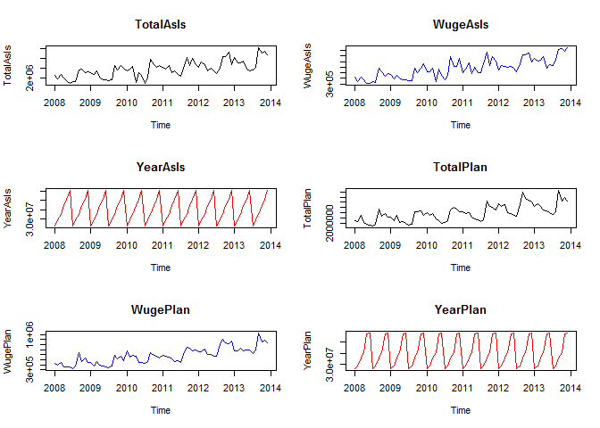

```r
par(mfrow=c(3,2))
##Plot "AS IS" datasets
plot(TotalAsIs, col="black", main="TotalAsIs")
plot(WugeAsIs, col="blue", main="WugeAsIs")
plot(YearAsIs, col="red", main="YearAsIs")
##Plot "PLAN" datasets
plot(TotalPlan , col="black", main="TotalPlan")
plot(WugePlan, col="blue", main="WugePlan")
plot(YearPlan, col="red", main="YearPlan")
```

* STL Plots for AS IS WUGE Monthly 2008-2013 * STL Plots for AS IS Totals Monthly 2008-2013  
* STL Plots for AS IS Year End 2008-2013

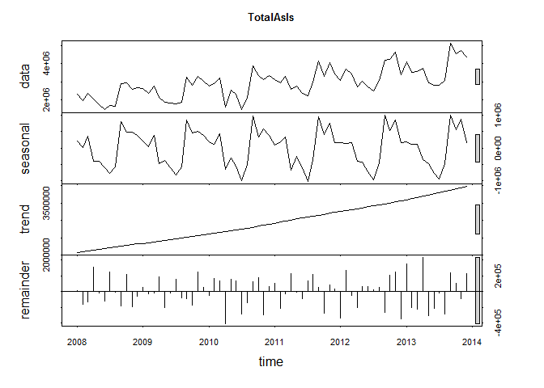

```r
par(mfrow=c(3,2))
plot(TotalAsIs_stl, col="black", main="TotalAsIs")
```

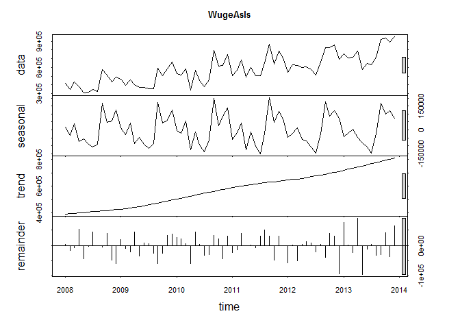

```r
plot(WugeAsIs_stl, col="black", main="WugeAsIs")
```

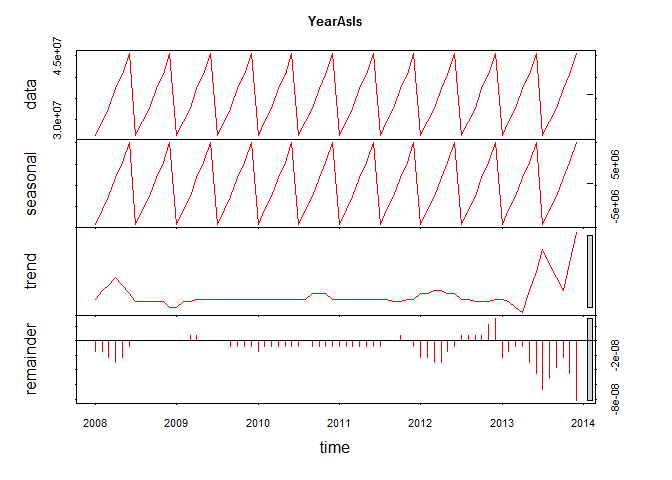

```r
plot(YearAsIs_stl, col="red", main="YearAsIs")
```

* Trend Plots for AS IS WUGE Monthly 2008-2013 * Trend Plots for AS IS Totals Monthly 2008-2013  
* Trend Plots for AS IS Year End 2008-2013

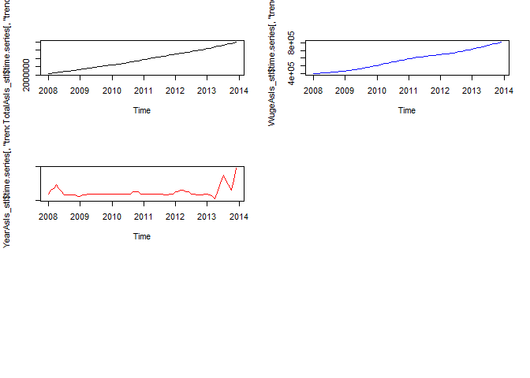

```r
par(mfrow=c(3,2))
plot(TotalAsIs_stl$time.series[,"trend"], col="black")
plot(WugeAsIs_stl$time.series[,"trend"], col="blue")
plot(YearAsIs_stl$time.series[,"trend"], col="red")
```

* Monthly Seasonal Plots for AS IS WUGE Monthly 2008-2013 * Monthly Seasonal Plots for AS IS Totals Monthly 2008-2013  
* Monthly Seasonal Plots for AS IS Year End 2008-2013

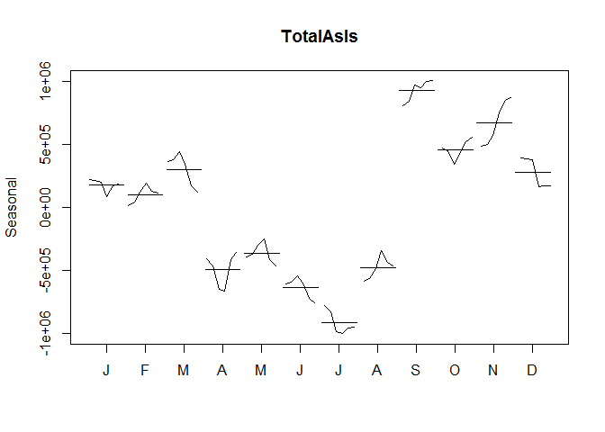

```r
monthplot(TotalAsIs_stl$time.series[,"seasonal"], main="TotalAsIs", ylab="Seasonal")
```

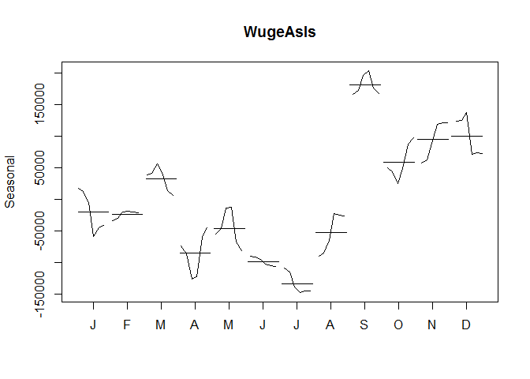

```r
monthplot(WugeAsIs_stl$time.series[,"seasonal"], main="WugeAsIs", ylab="Seasonal")
```

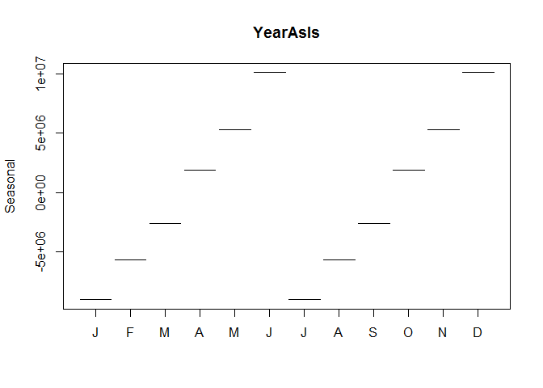

```r
monthplot(YearAsIs_stl$time.series[,"seasonal"], main="YearAsIs", ylab="Seasonal")
```

### **Exploring Forcast Models**

###### **Simple expontential smoothing.**

```r
##2014 Monthly Forcast values
Model_ses <- ses(TotalAsIs, h=12)
summary(Model_ses)
```

```
##
## Forecast method: Simple exponential smoothing
##
## Model Information:
## Simple exponential smoothing
##
## Call:
##  ses(x = TotalAsIs, h = 12)
##
##   Smoothing parameters:
##     alpha = 0.671
##
##   Initial states:
##     l = 2173226.7433
##
##   sigma:  609507
##
##      AIC     AICc      BIC
## 2230.058 2230.232 2234.612
##
## Error measures:
##                    ME   RMSE      MAE       MPE     MAPE     MASE
## Training set 47469.84 609507 429997.1 -1.511008 15.02336 1.172074
##                    ACF1
## Training set 0.02384493
##
## Forecasts:
##          Point Forecast   Lo 80   Hi 80   Lo 95   Hi 95
## Jan 2014        4466448 3685333 5247562 3271836 5661059
## Feb 2014        4466448 3525801 5407094 3027853 5905042
## Mar 2014        4466448 3389650 5543245 2819628 6113267
## Apr 2014        4466448 3268880 5664015 2634926 6297969
## May 2014        4466448 3159220 5773675 2467215 6465680
## Jun 2014        4466448 3058072 5874823 2312524 6620371
## Jul 2014        4466448 2963718 5969177 2168221 6764674
## Aug 2014        4466448 2874947 6057948 2032458 6900437
## Sep 2014        4466448 2790873 6142022 1903878 7029017
## Oct 2014        4466448 2710821 6222074 1781448 7151447
## Nov 2014        4466448 2634263 6298632 1664363 7268532
## Dec 2014        4466448 2560778 6372117 1551977 7380918
```

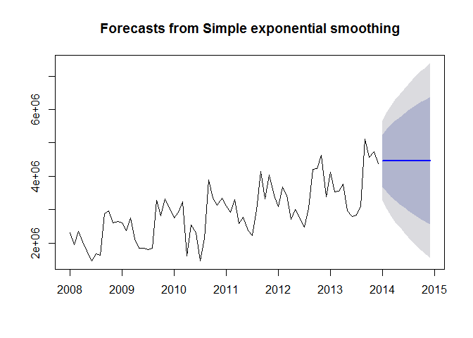

```r
plot(Model_ses)
```

#### **HOLT’S Method.**

###### **Holt’s linear Method**

```r
##2014 Monthly Forcast values
Model_holt_1 <- holt(TotalAsIs,h=12)
summary(Model_holt_1)
```

```
##
## Forecast method: Holt's method
##
## Model Information:
## Holt's method
##
## Call:
##  holt(x = TotalAsIs, h = 12)
##
##   Smoothing parameters:
##     alpha = 0.6571
##     beta  = 1e-04
##
##   Initial states:
##     l = 2040390.7764
##     b = 45050.7514
##
##   sigma:  608119.1
##
##      AIC     AICc      BIC
## 2233.730 2234.327 2242.837
##
## Error measures:
##                    ME     RMSE      MAE      MPE     MAPE     MASE
## Training set -16586.9 608119.1 441110.7 -3.88925 15.75307 1.202367
##                    ACF1
## Training set 0.03462672
##
## Forecasts:
##          Point Forecast   Lo 80   Hi 80   Lo 95   Hi 95
## Jan 2014        4536367 3757031 5315703 3344475 5728259
## Feb 2014        4581298 3648703 5513894 3155016 6007580
## Mar 2014        4626230 3562188 5690271 2998918 6253541
## Apr 2014        4671161 3490181 5852141 2865008 6477314
## May 2014        4716092 3428721 6003463 2747228 6684956
## Jun 2014        4761024 3375378 6146669 2641862 6880185
## Jul 2014        4805955 3328531 6283379 2546429 7065480
## Aug 2014        4850886 3287035 6414738 2459182 7242591
## Sep 2014        4895818 3250047 6541588 2378829 7412807
## Oct 2014        4940749 3216925 6664573 2304387 7577111
## Nov 2014        4985680 3187164 6784196 2235088 7736273
## Dec 2014        5030612 3160363 6900860 2170314 7890909
```

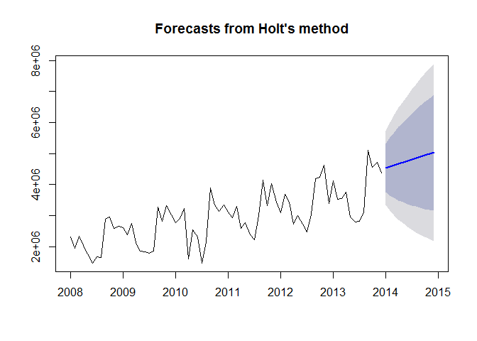

```r
plot(Model_holt_1)
```

###### **Holt’s exponential Method.**

```r
##2014 Monthly Forcast values
Model_holt_2<- holt(TotalAsIs, exponential=TRUE,h=12)
summary(Model_holt_2)
```

```
##
## Forecast method: Holt's method with exponential trend
##
## Model Information:
## Holt's method with exponential trend
##
## Call:
##  holt(x = TotalAsIs, h = 12, exponential = TRUE)
##
##   Smoothing parameters:
##     alpha = 0.6637
##     beta  = 1e-04
##
##   Initial states:
##     l = 2041538.9468
##     b = 1.0029
##
##   sigma:  0.2438
##
##      AIC     AICc      BIC
## 2251.010 2251.607 2260.116
##
## Error measures:
##                    ME     RMSE      MAE       MPE     MAPE     MASE
## Training set 37825.61 609787.5 433018.9 -1.838214 15.18487 1.180311
##                    ACF1
## Training set 0.02918287
##
## Forecasts:
##          Point Forecast   Lo 80   Hi 80   Lo 95    Hi 95
## Jan 2014        4488281 3122757 5920370 2400046  6614985
## Feb 2014        4502175 2911211 6183146 2159658  7194620
## Mar 2014        4516113 2680175 6456311 1937508  7770509
## Apr 2014        4530094 2519235 6802900 1815156  8472860
## May 2014        4544118 2385838 6940131 1686948  8983095
## Jun 2014        4558186 2301475 7214211 1546232  9297065
## Jul 2014        4572297 2157964 7337924 1454917  9830322
## Aug 2014        4586452 2060263 7616518 1364990 10197938
## Sep 2014        4600650 1980854 7812667 1295591 10801316
## Oct 2014        4614893 1875974 8000331 1248812 11022718
## Nov 2014        4629180 1830506 8128349 1141138 11267376
## Dec 2014        4643510 1752931 8217698 1071445 11859434
```

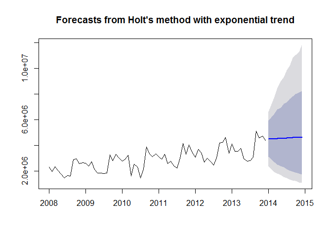

```r
plot(Model_holt_2)
```

###### **Holt’s Damped Linear Method.**

```r
##2014 Monthly Forcast values
Model_holt_3 <- holt(TotalAsIs, damped=TRUE,h=12)
summary(Model_holt_3)
```

```
##
## Forecast method: Damped Holt's method
##
## Model Information:
## Damped Holt's method
##
## Call:
##  holt(x = TotalAsIs, h = 12, damped = TRUE)
##
##   Smoothing parameters:
##     alpha = 0.6613
##     beta  = 2e-04
##     phi   = 0.98
##
##   Initial states:
##     l = 2040392.5761
##     b = 45053.25
##
##   sigma:  608787.2
##
##      AIC     AICc      BIC
## 2235.888 2236.797 2247.272
##
## Error measures:
##                    ME     RMSE      MAE       MPE     MAPE     MASE
## Training set 15578.94 608787.2 436909.7 -2.797612 15.46526 1.190916
##                    ACF1
## Training set 0.03351419
##
## Forecasts:
##          Point Forecast   Lo 80   Hi 80   Lo 95   Hi 95
## Jan 2014        4483618 3703426 5263811 3290417 5676819
## Feb 2014        4493914 3558436 5429391 3063224 5924603
## Mar 2014        4504003 3435520 5572486 2869899 6138107
## Apr 2014        4513891 3327168 5700614 2698955 6328827
## May 2014        4523581 3229332 5817829 2544198 6502963
## Jun 2014        4533077 3139534 5926619 2401837 6664316
## Jul 2014        4542383 3056128 6028638 2269352 6815413
## Aug 2014        4551503 2977955 6125051 2144969 6958036
## Sep 2014        4560440 2904162 6216719 2027381 7093499
## Oct 2014        4569199 2834101 6304298 1915595 7222803
## Nov 2014        4577783 2767264 6388301 1808834 7346732
## Dec 2014        4586195 2703249 6469141 1706477 7465913
```

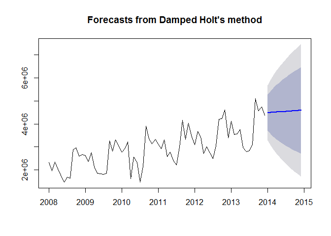

```r
plot(Model_holt_3)
```

###### **Holt’s Damped Exponential Method.**

```r
##2014 Monthly Forcast values
Model_holt_4 <- holt(TotalAsIs, exponential=TRUE, damped=TRUE,h=12)
summary(Model_holt_4)
```

```
##
## Forecast method: Damped Holt's method with exponential trend
##
## Model Information:
## Damped Holt's method with exponential trend
##
## Call:
##  holt(x = TotalAsIs, h = 12, damped = TRUE, exponential = TRUE)
##
##   Smoothing parameters:
##     alpha = 0.6679
##     beta  = 1e-04
##     phi   = 0.9799
##
##   Initial states:
##     l = 2041541.9705
##     b = 1.0019
##
##   sigma:  0.2449
##
##      AIC     AICc      BIC
## 2253.216 2254.125 2264.600
##
## Error measures:
##                    ME     RMSE      MAE       MPE     MAPE     MASE
## Training set 46119.56 609906.7 432069.1 -1.549114 15.11987 1.177722
##                   ACF1
## Training set 0.0254941
##
## Forecasts:
##          Point Forecast   Lo 80   Hi 80   Lo 95    Hi 95
## Jan 2014        4470648 3066707 5863519 2257222  6562504
## Feb 2014        4473164 2816046 6224769 2085417  7362134
## Mar 2014        4475630 2616109 6520350 1940485  7866715
## Apr 2014        4478047 2418959 6776698 1770335  8485145
## May 2014        4480418 2328519 7010272 1648408  9091099
## Jun 2014        4482742 2195078 7194100 1496346  9460193
## Jul 2014        4485020 2072638 7314696 1402991 10193253
## Aug 2014        4487253 1946515 7553011 1315892 10273884
## Sep 2014        4489443 1877246 7871872 1213897 10608708
## Oct 2014        4491589 1801228 8000540 1162851 11115061
## Nov 2014        4493694 1725411 8122747 1051269 11378645
## Dec 2014        4495757 1658818 8243889 1006989 11811924
```

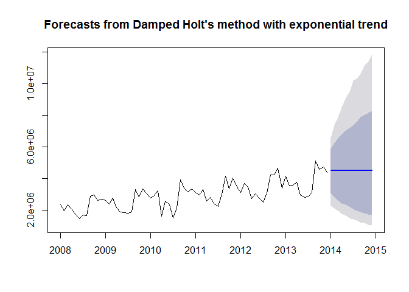

```r
plot(Model_holt_4)
```

###### **Model Comparison Holt’s Linear, Holt’s Exponential, Holt’s Damped Linear, Holt’s Damped Exponential and Simple expontential smoothing.**

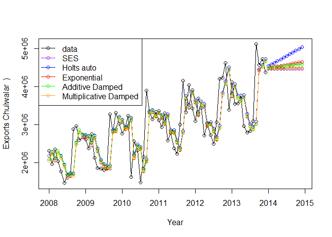

```r
plot.new()
par(mfrow=c(1,1))
plot(Model_holt_1, plot.conf=FALSE, ylab="Exports Chulwalar  )", xlab="Year", main="", fcol="white", type="o")
lines(fitted(Model_ses), col="purple", type="o")
lines(fitted(Model_holt_1), col="blue", type="o")
lines(fitted(Model_holt_2), col="red", type="o")
lines(fitted(Model_holt_3), col="green", type="o")
lines(fitted(Model_holt_4), col="orange", type="o")
lines(Model_ses$mean, col="purple", type="o")
lines(Model_holt_1$mean, col="blue", type="o")
lines(Model_holt_2$mean, col="red", type="o")
lines(Model_holt_3$mean, col="green", type="o")
lines(Model_holt_4$mean, col="orange", type="o")
legend("topleft",lty=1, col=c(1,"purple","blue","red","green","orange"), c("data", "SES","Holts auto", "Exponential", "Additive Damped", "Multiplicative Damped"),pch=1)
```